# Getting Started with smoothbp

## Overview

`smoothbp` fits hierarchical piecewise regression models with **multiple change-points**, each smoothed by a logistic sigmoid. The general mean function for $K$ change-points is:

$$\mu_i = b0_i + b1_i(\tau_i - \omega_{1i}) +
\sum_{k=1}^{K} \delta_{ki}(\tau_i - \omega_{ki})\,
\text{logistic}\!\left[(\tau_i - \omega_{ki})\rho_{ki}\right]$$

where

| Symbol | Role |
| --- | --- |
| $\tau$ | time / covariate |
| $\omega_k$ | location of the $k$-th change-point |
| $\rho_k$ | transition sharpness for change-point $k$ ($\rho \to \infty$ → hard kink) |
| $b0$ | level at the first change-point |
| $b1$ | pre-change slope (anchored at $\omega_1$) |
| $\delta_k$ | slope change attributable to change-point $k$ |

When $K = 0$ the model reduces to a standard hierarchical linear regression. When $K = 1$ it matches the classic two-phase piecewise model.

Each parameter has its own linear predictor specified via a formula. `b0` may also include a random intercept `(1 | group)` for clustered / repeated-measures data.

Posterior inference uses a **Metropolis-within-Gibbs sampler written in Rust**:

- $b0$, $b1$, $\delta_k$, random intercepts — exact Gibbs (conjugate normal).
- $\omega_k$, $\rho_k$ — Hamiltonian Monte Carlo with adaptive mass matrix during warmup.
- $\sigma$, $\sigma_u$ — exact Gibbs (inverse-gamma conjugate).
- $\gamma_k$ (spike-and-slab) — Gibbs with Bernoulli likelihood.

## Real-World Applications

While `smoothbp` is a general-purpose statistical tool, it is uniquely powerful for modeling structural changes across various scientific domains:

- **Pharmacokinetics / Medicine**: Modeling the delayed onset of a drug’s effect and identifying the precise time threshold where clearance rates exponentially shift.
- **Ecology / Climate Science**: Identifying “tipping points” where species population growth trajectories abruptly change in response to accumulated temperature variations.
- **Epidemiology**: Tracking structural shifts in infection rates ($R_0$) to pinpoint exactly when a public health intervention successfully flattened the curve.
- **Finance**: Discovering the exact timing of market regime shifts and measuring how individual assets respond differently to global economic shocks.

## Simulating data

`simulate_smoothbp()` generates synthetic data from the model. It is useful for testing and for understanding how the parameters relate to the observable trajectory shape.

```r
library(smoothbp)

dat <- simulate_smoothbp(
  n_subj    = 20,
  n_obs     = 8,
  b0        = 5.0,   # level at change-point
  b1        = -0.3,  # pre-change slope
  delta     =  1.2,  # slope change (delta_1)
  omega     =  3.0,  # change-point location
  rho       =  4.0,  # transition sharpness
  sigma     =  0.4,  # residual SD
  sigma_u   =  0.5,  # between-subject SD
  tau_range = c(0, 6),
  seed      = 42
)

head(dat)
```

```
#>   subject       tau       mu        y
#> 1       1 0.0000000 6.585457 6.462802
#> 2       1 0.8571429 6.327849 5.615326
#> 3       1 1.7142857 6.062234 5.993467
#> 4       1 2.5714286 5.735566 6.221436
#> 5       1 3.4285714 5.992709 6.750786
#> 6       1 4.2857143 6.833663 6.661475
```

```r
true_params(dat)
```

```
#> Data-generating parameters:
#>   b0:        5
#>   b1:        -0.3
#>   sigma:     0.4
#>   sigma_u:   0.5
#>   seed:      42
#>   omega[1]:  3
#>   delta[1]:  1.2
#>   rho[1]:    4
```

## Fitting the model

### Zero change-points (linear fallback)

When `deltas`, `omega`, and `rho` are empty lists, `smoothbp` fits a standard hierarchical linear regression:

```r
fit0 <- smoothbp(
  formula = y ~ tau,
  b0      = ~ 1 + (1 | subject),
  b1      = ~ 1,
  deltas  = list(),   # no change-points
  omega   = list(),
  rho     = list(),
  data    = dat,
  chains  = 2L, iter = 1000L, warmup = 500L, seed = 42L, .verbose = FALSE
)
summary(fit0)
```

```
#>         variable  mean    SD  Q2.5 Q97.5  Rhat Bulk_ESS Tail_ESS
#> 1 b0_(Intercept) 5.232 0.188 4.842 5.579 1.035   90.196  118.810
#> 2 b1_(Intercept) 0.282 0.029 0.225 0.336 0.999 1011.287 1025.573
#> 3          sigma 0.749 0.046 0.665 0.846 1.001  767.417  814.709
#> 4        sigma_u 0.697 0.128 0.496 0.998 0.999  629.709  872.569
```

### One change-point

```r
fit1 <- smoothbp(
  formula = y ~ tau,
  b0      = ~ 1 + (1 | subject),
  b1      = ~ 1,
  deltas  = list(~ 1),          # one slope change
  omega   = list(~ 1),          # one change-point location
  rho     = list(~ 1),          # one sharpness
  data    = dat,
  priors  = smoothbp_priors(
    omega = list(prior_normal(3, 2, lb = 0))
  ),
  chains  = 4L, iter = 2000L, warmup = 1000L, seed = 42L
)
```

```
#> Building design matrices...
#> Running sampler...
```

```r
summary(fit1)
```

```
#>             variable   mean    SD   Q2.5  Q97.5  Rhat Bulk_ESS Tail_ESS
#> 1     b0_(Intercept)  5.118 0.173  4.772  5.451 1.046   90.259  265.474
#> 2     b1_(Intercept) -0.322 0.048 -0.418 -0.226 1.005  768.375 1832.749
#> 3 delta1_(Intercept)  1.156 0.067  1.028  1.288 1.000 2951.484 3794.999
#> 4 omega1_(Intercept)  2.906 0.121  2.657  3.128 1.008  367.031  552.253
#> 5   rho1_(Intercept)  3.249 1.504  1.335  6.871 1.001  616.800  579.182
#> 6              sigma  0.400 0.024  0.356  0.450 1.002 2725.862 3394.393
#> 7            sigma_u  0.715 0.121  0.525  1.004 1.001 2489.879 3524.422
```

### Multiple change-points (The List-of-Formulas API)

For models with multiple structural breaks, `smoothbp` uses a “List-of-Formulas” API. You pass lists of equal length to `deltas`, `omega`, and `rho`. Each element in the list corresponds to the sub-model for that specific breakpoint.

```r
# Fit a model with 3 candidate breakpoints
fit3 <- smoothbp(
  formula = y ~ tau,
  b0      = ~ 1 + (1 | subject),
  b1      = ~ 1,
  # Each segment gets its own formula (here, just an intercept)
  deltas  = list(~ 1, ~ 1, ~ 1),
  omega   = list(~ 1, ~ 1, ~ 1),
  rho     = list(~ 1, ~ 1, ~ 1),
  data    = dat,
  priors  = smoothbp_priors(
    # Use the space_omega_priors helper to initialize the search
    omega = space_omega_priors(K = 3, tau_min = 0, tau_max = 6)
  )
)
```

```
#> Building design matrices...
#> Running sampler...
```

### Known Change-Points with `fixed()`

If you are performing an intervention analysis (e.g., a Regression Discontinuity Design or a Stepped-Wedge trial), you may already know exactly where the change points should be.

By using the `fixed()` helper, you tell the model **not** to estimate the location or sharpness, but only the magnitude of the change ($\delta$). This is much faster and allows for direct hypothesis testing of the intervention effect.

```r
# Test for a hard kink at exactly tau = 3.0
fit_fixed <- smoothbp_ss(
  formula = y ~ tau,
  omega   = list(fixed(3.0)),   # Location is known
  rho     = list(fixed(100)),   # Sharpness is fixed (hard kink)
  data    = dat
)
```

```
#> Building design matrices...
#> Running sampler...
```

```r
# The PIP tells us the probability that the intervention had an effect
pip(fit_fixed)
```

```
#>           Parameter PIP Lower 95% Upper 95%
#>      b1_(Intercept)   1     0.999         1
#>  delta1_(Intercept)   1     0.999         1
```

> **Note**: `fixed()` can also accept a vector of the same length as your data, allowing for observation-specific change points (e.g., different intervention times per cluster).

> **Tip**: If you are unsure how many change-points are present, use `smoothbp_ss()` with spike-and-slab regularization — see `vignette("spike-and-slab")`.

### Progress and parallel chains

```r
fit1 <- smoothbp(
  formula = y ~ tau,
  b0      = ~ 1 + (1 | subject),
  data    = dat,
  chains  = 4L, iter = 2000L, warmup = 1000L, seed = 42L,
  cores   = 4L    # run all 4 chains concurrently
)
```

```
#> Building design matrices...
#> Running sampler...
```

To make parallel the default for a project, add this to `.Rprofile`:

```r
options(smoothbp.cores = parallel::detectCores())
```

## Posterior summary

`print()` displays results in distinct, labelled sections; `summary()` returns a clean data frame. By default, `effects = c("fixed", "ran_pars")` is used, matching the conventions of other mixed-modeling packages like `brms`.

You can filter which parameters are returned or printed by passing a vector to the `effects` argument. The parameters are classified into three strict categories: 1. `"fixed"`: Population-level structural parameters ($b0, b1, \delta, \omega, \rho, \sigma$) 2. `"ran_pars"`: Group-level variance parameters (e.g., `sigma_u`) 3. `"ran_vals"`: The actual group-level deviations (e.g., the individual `u[j]` random intercepts)

```r
print(fit1)                                        # fixed + ran_pars (default)
```

```
#> Smooth Change-Point Model (smoothbp)
#> -------------------------------------
#> Response : y
#> Time var : tau
#> Chains   : 4 × 1000 draws (1000 warmup)
#>
#> Group-Level Effects (Parameters):
#>  variable  mean    SD  Q2.5 Q97.5 Rhat Bulk_ESS Tail_ESS
#>   sigma_u 0.715 0.121 0.525 0.988    1 3102.972 3700.256
#>
#> Population-Level Effects:
#>            variable   mean    SD   Q2.5  Q97.5  Rhat Bulk_ESS Tail_ESS
#>      b0_(Intercept)  5.105 0.175  4.783  5.464 1.041  119.509  265.572
#>      b1_(Intercept) -0.324 0.052 -0.430 -0.228 1.003  603.810 1033.071
#>  delta1_(Intercept)  1.154 0.069  1.022  1.295 1.002 2434.347 3224.431
#>  omega1_(Intercept)  2.897 0.132  2.625  3.135 1.005  326.276  624.749
#>    rho1_(Intercept)  3.078 1.484  1.240  6.727 1.005  385.747  209.469
#>               sigma  0.402 0.025  0.357  0.452 1.001 3020.667 3723.235
```

```r
print(fit1, effects = "fixed")                     # population-level only
```

```
#> Smooth Change-Point Model (smoothbp)
#> -------------------------------------
#> Response : y
#> Time var : tau
#> Chains   : 4 × 1000 draws (1000 warmup)
#>
#> Population-Level Effects:
#>            variable   mean    SD   Q2.5  Q97.5  Rhat Bulk_ESS Tail_ESS
#>      b0_(Intercept)  5.105 0.175  4.783  5.464 1.041  119.509  265.572
#>      b1_(Intercept) -0.324 0.052 -0.430 -0.228 1.003  603.810 1033.071
#>  delta1_(Intercept)  1.154 0.069  1.022  1.295 1.002 2434.347 3224.431
#>  omega1_(Intercept)  2.897 0.132  2.625  3.135 1.005  326.276  624.749
#>    rho1_(Intercept)  3.078 1.484  1.240  6.727 1.005  385.747  209.469
#>               sigma  0.402 0.025  0.357  0.452 1.001 3020.667 3723.235
```

```r
summary(fit1, effects = "all")                     # returns everything, including u[j]
```

```
#>              variable   mean    SD   Q2.5  Q97.5  Rhat Bulk_ESS Tail_ESS
#> 1      b0_(Intercept)  5.105 0.175  4.783  5.464 1.041  119.509  265.572
#> 2                u[1]  0.530 0.208  0.116  0.933 1.028  170.892  356.604
#> 3                u[2] -0.312 0.203 -0.723  0.082 1.031  165.734  341.879
#> 4                u[3] -0.076 0.207 -0.484  0.319 1.029  171.511  387.884
#> 5                u[4]  0.224 0.203 -0.179  0.618 1.026  175.442  365.057
#> 6                u[5]  0.171 0.205 -0.240  0.574 1.024  179.182  400.240
#> 7                u[6]  0.080 0.204 -0.322  0.479 1.026  180.637  426.099
#> 8                u[7]  0.684 0.201  0.280  1.062 1.028  169.810  320.180
#> 9                u[8] -0.050 0.200 -0.449  0.336 1.027  172.813  374.142
#> 10               u[9]  0.997 0.206  0.579  1.404 1.026  190.876  435.610
#> 11              u[10] -0.166 0.204 -0.568  0.223 1.022  186.522  390.003
#> 12              u[11]  0.674 0.203  0.268  1.062 1.024  179.493  415.923
#> 13              u[12]  0.921 0.203  0.517  1.300 1.030  168.359  438.745
#> 14              u[13] -0.857 0.205 -1.279 -0.473 1.026  170.368  447.100
#> 15              u[14] -0.380 0.204 -0.799  0.017 1.024  173.321  387.990
#> 16              u[15] -0.016 0.205 -0.434  0.383 1.021  196.314  395.075
#> 17              u[16]  0.172 0.202 -0.226  0.563 1.029  179.558  399.941
#> 18              u[17] -0.319 0.205 -0.730  0.067 1.028  175.109  317.544
#> 19              u[18] -1.399 0.203 -1.816 -1.023 1.024  179.082  331.625
#> 20              u[19] -1.075 0.203 -1.485 -0.678 1.019  189.787  403.049
#> 21              u[20]  0.598 0.205  0.188  1.000 1.032  172.373  390.611
#> 22     b1_(Intercept) -0.324 0.052 -0.430 -0.228 1.003  603.810 1033.071
#> 23 delta1_(Intercept)  1.154 0.069  1.022  1.295 1.002 2434.347 3224.431
#> 24 omega1_(Intercept)  2.897 0.132  2.625  3.135 1.005  326.276  624.749
#> 25   rho1_(Intercept)  3.078 1.484  1.240  6.727 1.005  385.747  209.469
#> 26              sigma  0.402 0.025  0.357  0.452 1.001 3020.667 3723.235
#> 27            sigma_u  0.715 0.121  0.525  0.988 1.000 3102.972 3700.256
```

Parameter names follow the convention:

| Name | Meaning |
| --- | --- |
| `b0_(Intercept)` | Intercept (level at first change-point) |
| `b1_(Intercept)` | Pre-change slope |
| `delta1_(Intercept)` | Slope change at change-point 1 |
| `omega1_(Intercept)` | Change-point 1 location |
| `rho1_(Intercept)` | Change-point 1 sharpness |
| `sigma` | Residual SD |
| `sigma_u` | Between-group SD (random intercept) |

## Diagnostics

### Trace plots with mixing indicators

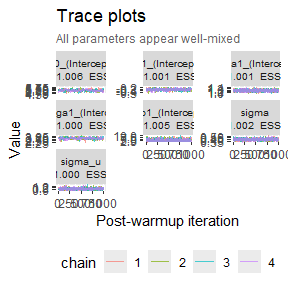

```r
plot(fit1)        # alias for trace_plot(fit1)
```

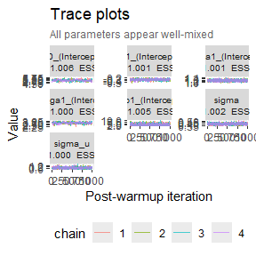

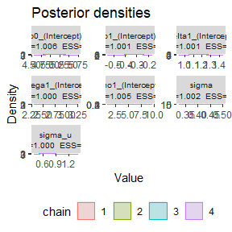

```r
trace_plot(fit1, type = "both")   # trace + density
```

Parameters with $\hat{R} > 1.05$ or bulk-ESS $< 100$ are flagged with a ⚠ symbol and a red-tinted background. Thresholds are adjustable:

```
#> 3 parameter(s) flagged (Rhat > 1.01 or ESS < 400): b0_(Intercept) (1.006), omega1_(Intercept) (1.000), rho1_(Intercept) (1.005)
```

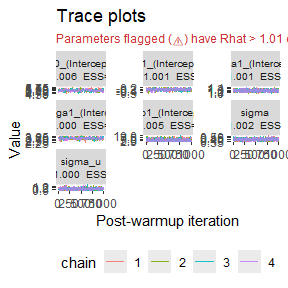

```r
trace_plot(fit1, rhat_thresh = 1.01, ess_thresh = 400)
```

### Posterior predictive check

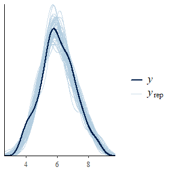

```r
pp_check(fit1)
```

## Prior specification

`smoothbp_priors()` accepts either a single prior applied to all coefficients of a component, or a named list. For multi-breakpoint models, `omega` and `rho` accept a **list of priors** (one per breakpoint):

```r
smoothbp_priors(
  b0    = prior_normal(0, 10),
  b1    = prior_normal(0, 5),
  omega = list(
    prior_normal(2, 1),   # change-point 1
    prior_normal(5, 1)    # change-point 2
  ),
  rho   = list(
    prior_normal(4, 2, lb = 0),
    prior_normal(4, 2, lb = 0)
  ),
  sigma = prior_invgamma(shape = 2, scale = 1)
)
```

```
#> smoothbp priors:
#>   b0      : Normal(mean=0, sd=10)
#>   b1      : Normal(mean=0, sd=5)
#>   deltas  : Normal(mean=0, sd=2)
#>   omega   : <list of priors>
#>   rho     : <list of priors>
#>   sigma   : InvGamma(shape=2, scale=1)
#>   sigma_u : InvGamma(shape=1, scale=1)
#>   sigma_re_om: InvGamma(shape=1, scale=1)
```

The `lb` and `ub` arguments impose hard bounds. `rho` should typically have `lb = 0` (sharpness must be positive). For `omega` and `deltas`, it is often better to **avoid hard bounds** unless they are physically necessary for your domain.

> **Performance Tip**: `smoothbp` is significantly faster when `b1`, `deltas`, and `omega` are unconstrained. Without bounds, the sampler can use exact conjugate Gibbs updates for `b1` and `deltas`, and standard HMC for `omega`. Truncated priors require additional checks and rejection sampling steps.

If you do use bounds for `omega`, ensure they cover the actual range of your time variable (e.g. if your time starts at -10, do not use `lb = 0`).

## Breakpoint selection with spike-and-slab

When the number of change-points is unknown, fit a model with $K$ potential breakpoints using `smoothbp_ss()`. Each slope change $\delta_k$ has a binary inclusion indicator $\gamma_k$; the posterior mean of $\gamma_k$ is the **posterior inclusion probability (PIP)** for that breakpoint.

```r
fit_ss <- smoothbp_ss(
  formula = y ~ tau,
  b0      = ~ 1 + (1 | subject),
  b1      = ~ 1,
  deltas  = list(~ 1, ~ 1, ~ 1),   # 3 candidate breakpoints
  omega   = list(~ 1, ~ 1, ~ 1),
  rho     = list(~ 1, ~ 1, ~ 1),
  data    = dat,
  spike   = prior_spike_slab(pi = 0.1, learn_pi = TRUE),
  chains  = 4L, iter = 2000L, warmup = 1000L, seed = 42L
)
```

```
#> Building design matrices...
#> Running sampler...
```

```r
# Posterior inclusion probabilities per breakpoint
pip(fit_ss)
```

```
#>           Parameter   PIP Lower 95% Upper 95%
#>      b1_(Intercept) 1.000     0.999     1.000
#>  delta1_(Intercept) 0.760     0.747     0.773
#>  delta2_(Intercept) 0.753     0.739     0.766
#>  delta3_(Intercept) 0.780     0.767     0.793
#> gamma_delta1_(Intercept) gamma_delta2_(Intercept) gamma_delta3_(Intercept)
#>                    0.987                    0.063                    0.041
```

A PIP near 1 indicates that breakpoint is supported by the data; a low PIP indicates the slope change is not needed.

See `vignette("spike-and-slab")` for a full tutorial.

## Hypothesis tests and evidence ratios

`hypothesis()` evaluates directional hypotheses against the posterior draws.

```r
# Is the slope change at breakpoint 1 positive?
smoothbp::hypothesis(fit1, "delta1_(Intercept) > 0")
```

```
#> Hypothesis tests for smoothbp_fit  (4000 posterior draws)
#> Credible interval: 95%   Evidence ratio = P(H) / (1 - P(H))
#> Stars: *** ER > 99  ** ER > 19  * ER > 3
#> ------------------------------------------------------------------------
#>              Hypothesis Estimate Est.Error CI.lo(95%) CI.hi(95%) P(H) Evid.Ratio Star
#>  delta1_(Intercept) > 0    1.154     0.069      1.022      1.295    1        Inf  ***
```

```r
# Complex linear hypothesis: is the final slope (b1 + delta1) negative?
smoothbp::hypothesis(fit1, "b1_(Intercept) + delta1_(Intercept) < 0")
```

```
#> Hypothesis tests for smoothbp_fit  (4000 posterior draws)
#> Credible interval: 95%   Evidence ratio = P(H) / (1 - P(H))
#> Stars: *** ER > 99  ** ER > 19  * ER > 3
#> ------------------------------------------------------------------------
#>                               Hypothesis Estimate Est.Error CI.lo(95%) CI.hi(95%) P(H) Evid.Ratio Star
#>  b1_(Intercept) + delta1_(Intercept) < 0    -0.83     0.052     -0.934     -0.731    0          0
```

```r
# Does the change-point fall before time 4?
smoothbp::hypothesis(fit1, "omega1_(Intercept) < 4")
```

```
#> Hypothesis tests for smoothbp_fit  (4000 posterior draws)
#> Credible interval: 95%   Evidence ratio = P(H) / (1 - P(H))
#> Stars: *** ER > 99  ** ER > 19  * ER > 3
#> ------------------------------------------------------------------------
#>              Hypothesis Estimate Est.Error CI.lo(95%) CI.hi(95%) P(H) Evid.Ratio Star
#>  omega1_(Intercept) < 4    1.102     0.132      0.865      1.375    1        Inf  ***
```

| Stars | ER | $P(H)$ |
| --- | --- | --- |
| `***` | > 99 | > 0.99 |
| `**` | > 19 | > 0.95 |
| `*` | > 3 | > 0.75 |

## Model comparison

### Leave-one-out cross-validation (LOO-IC)

```r
# Compare 0-BP (linear) vs 1-BP vs 3-BP models
loo0 <- loo(fit0)
loo1 <- loo(fit1)
loo3 <- loo(fit3)
loo::loo_compare(loo0, loo1, loo3)
```

```
#>        elpd_diff se_diff
#> model2    0.0       0.0
#> model3   -0.6       0.5
#> model1 -102.1       9.5
```

### Bayes factors via bridge sampling

```r
library(bridgesampling)
bs0 <- bridge_sampler(fit0)
bs1 <- bridge_sampler(fit1)
bayes_factor(bs1, bs0)
```

```
#> Estimated Bayes factor in favor of x1 over x2: 647279726565943701800222600602626062.00000
```

## Extracting results

### Fitted values

```r
# Posterior mean + 95% CI at training observations
fitted(fit1)
```

```
#>     .observation fitted_mean fitted_Q2.5 fitted_Q97.5
#> 1              1    6.555453    6.244437     6.885620
#> 2              2    6.257818    5.962741     6.556340
#> 3              3    5.935973    5.634113     6.243700
#> 4              4    5.644186    5.338119     5.954130
#> 5              5    5.956380    5.650674     6.271502
#> 6              6    6.720588    6.417796     7.017241
#> 7              7    7.469637    7.173221     7.761729
#> 8              8    8.196094    7.879141     8.509982
#> 9              9    5.713628    5.408868     6.032243
#> 10            10    5.415992    5.141878     5.709818
#> 11            11    5.094147    4.790414     5.395700
#> 12            12    4.802361    4.499751     5.097668
#> 13            13    5.114555    4.813589     5.409359
#> 14            14    5.878762    5.596792     6.159715
```

[output cut: 146 more lines]

```r
# Full posterior draws matrix (n_draws × n_obs)
draws_mat <- fitted(fit1, summary = FALSE)
```

### Working with `posterior` draws

The `$draws` component of a `smoothbp` fit is a standard `draws_array` object from the `posterior` package. You can use any of the `posterior` tools to manipulate and summarize the draws.

```r
library(posterior)

# Convert to a data frame for use with ggplot2
draws_df <- as_draws_df(fit1$draws)

# Extract a specific parameter
b1_draws <- draws_df$`b1_(Intercept)`

# Compute custom summaries
summarise_draws(fit1$draws, "mean", "sd", ~quantile(.x, c(0.1, 0.9)))
```

```
#> # A tibble: 27 × 5
#>    variable          mean    sd   `10%`   `90%`
#>    <chr>            <dbl> <dbl>   <dbl>   <dbl>
#>  1 b0_(Intercept)  5.10   0.175  4.88    5.33
#>  2 u[1]            0.530  0.208  0.260   0.787
#>  3 u[2]           -0.312  0.203 -0.570  -0.0591
#>  4 u[3]           -0.0764 0.207 -0.340   0.186
#>  5 u[4]            0.224  0.203 -0.0352  0.481
#>  6 u[5]            0.171  0.205 -0.0847  0.436
#>  7 u[6]            0.0796 0.204 -0.184   0.338
#>  8 u[7]            0.684  0.201  0.415   0.941
#>  9 u[8]           -0.0495 0.200 -0.308   0.206
#> 10 u[9]            0.997  0.206  0.735   1.26
#> # ℹ 17 more rows
```

### Marginal predictions

```r
# Population-level predictions at new time points
newdata_marginal <- data.frame(tau = seq(0, 6, by = 0.1))
fitted(fit1, newdata = newdata_marginal)
```

```
#>    .observation fitted_mean fitted_Q2.5 fitted_Q97.5
#> 1             1    6.025581    5.699881     6.381106
#> 2             2    5.991702    5.669549     6.344827
#> 3             3    5.957645    5.639453     6.304985
#> 4             4    5.923393    5.607946     6.267319
#> 5             5    5.888925    5.575051     6.227596
#> 6             6    5.854217    5.541908     6.188975
#> 7             7    5.819247    5.510225     6.150098
#> 8             8    5.783990    5.476532     6.112731
#> 9             9    5.748421    5.442508     6.072842
#> 10           10    5.712514    5.407901     6.037070
#> 11           11    5.676248    5.372815     5.999997
#> 12           12    5.639599    5.337729     5.961219
#> 13           13    5.602554    5.300423     5.925772
#> 14           14    5.565104    5.259955     5.886758
```

[output cut: 47 more lines]

### Conditional predictions

```r
# Subject-specific predictions
fitted(fit1, newdata = data.frame(tau = seq(0, 6, by = 0.1), subject = "1"))
```

```
#>    .observation fitted_mean fitted_Q2.5 fitted_Q97.5
#> 1             1    6.555453    6.244437     6.885620
#> 2             2    6.521574    6.213222     6.842179
#> 3             3    6.487517    6.180303     6.806383
#> 4             4    6.453265    6.148726     6.764669
#> 5             5    6.418797    6.118076     6.725539
#> 6             6    6.384089    6.086744     6.689935
#> 7             7    6.349119    6.053299     6.650929
#> 8             8    6.313862    6.019412     6.613735
#> 9             9    6.278293    5.984144     6.578549
#> 10           10    6.242386    5.948275     6.540037
#> 11           11    6.206120    5.910190     6.498575
#> 12           12    6.169471    5.873732     6.461267
#> 13           13    6.132426    5.835631     6.424172
#> 14           14    6.094977    5.798079     6.390988
```

[output cut: 47 more lines]

## Manuscript-ready reporting

`model_methods()` and `model_results()` generate structured, self-contained text reports from a fitted model. Both functions are designed to be readily adapted for use in a manuscript or report, **or** passed to a large language model (LLM): the output includes the full algebraic specification with every symbol defined and every parameter value or prior stated explicitly, so no package documentation is needed to interpret the report.

The return value of each function is the complete report as an invisible character string, so you can capture it for programmatic use:

```r
methods_txt <- model_methods(fit1)
results_txt <- model_results(fit1)
```

`model_methods()` also emits a brief convergence note: if any Rhat values exceed 1.05, effective sample sizes fall below 100, or divergent transitions are present, a warning is printed with suggested diagnostics so that model-specification issues can be caught before results are reported.

### Statistical Analysis section — `model_methods()`

`model_methods()` describes *how* the analysis was done. It produces:

- a narrative paragraph readily adapted for use in the Methods section,
- the formula syntax and structural equation with all symbols defined,
- the prior distribution for every parameter,
- the MCMC algorithm details (sampler type, chains, iterations, seed), and
- a convergence note: silent when all diagnostics pass, prominent when Rhat, ESS, or divergent transitions indicate a potential problem.

```r
model_methods(fit1)
```

```
#> ======================================================================
#> SMOOTHBP: STATISTICAL METHODS REPORT
#> ======================================================================
#>
#> ======================================================================
#> NARRATIVE  (paste into manuscript Methods section)
#> ======================================================================
#>
#> Bayesian hierarchical piecewise regression with logistic-smoothed transitions
#> (adapted from Bacon & Watts, 1971) was fitted to 160 observations from 20
#> groups using the smoothbp R package (version 0.2.4; Bindoff, 2026), powered by
#> a Rust-based Metropolis-within-Gibbs sampler. The model includes a single
#> candidate breakpoint in the 'tau' dimension. The model includes random
#> intercepts across 20 groups. Posterior inference used 4 Markov chains of 2000
#> iterations (1000 warmup), yielding 4000 post-warmup draws. Results are
#> summarised as posterior mean and 95% credible interval. Convergence was
#> assessed using the Gelman-Rubin diagnostic (Rhat < 1.05) and effective sample
#> size (ESS).
#>
#> ======================================================================
#> MODEL SPECIFICATION
#> ======================================================================
#>
#> Formula syntax:
#>   Response ~ Time : y ~ tau
#>   b0              : ~1 + (1 | subject)
#>   b1              : ~1
#>   delta[1]        : ~1
#>   omega[1]        : ~1
#>   rho[1]          : ~1
#>
#> Structural equation:
#>   y_{ij} = b_0 + u_{j} + b_1 * (tau - omega_1) + delta_1 * (tau - omega_1) * logistic(rho_1 * (tau - omega_1)) + epsilon_{ij}
#>
#> Parameter definitions:
#>   b_0      : Intercept (conditional mean at tau = omega_1)
#>   u_{j}    : Random intercept for group j, u_{j} ~ Normal(0, sigma_u^2)
#>   b_1      : Pre-breakpoint slope
#>   delta_1  : Change in slope at breakpoint 1
#>   omega_1  : Breakpoint 1 location
```

[output cut: 60 more lines]

```
#>   ## priors: see Prior Distributions section above
#>   chains  = 4L, iter = 2000L, warmup = 1000L,
#>   seed    = 42L
#> )
#>
#> ======================================================================
#> REFERENCES
#> ======================================================================
#>
#> Bacon, D. W. & Watts, D. G. (1971). Estimating the transition between two intersecting straight lines. Biometrika, 58(3), 525-534. doi:10.2307/2334389
#>
#> Kuo, L. & Mallick, B. (1998). Variable selection for regression models. Sankhya: The Indian Journal of Statistics, 60(1), 65-81.
#>
#> Bindoff, A. D. (2026). smoothbp: Hierarchical Piecewise Regression with Smoothed Change-Points. R package version 0.2.4. https://github.com/ABindoff/smoothbp
#> ======================================================================
```

### Results section — `model_results()`

`model_results()` describes *what was found*. It produces:

- a narrative paragraph readily adapted for use in the Results section,
- the fitted model equation with posterior mean coefficients substituted to 3 d.p. (both the algebraic form and the fully numerical version),
- the asymptotic pre- and post-breakpoint slopes derived from $b1$ and $\delta_k$,
- per-breakpoint summaries (location, sharpness, slope change, all with 95% credible intervals),
- the full posterior estimates table, and
- convergence diagnostics.

```r
model_results(fit1)
```

```
#> ======================================================================
#> SMOOTHBP: RESULTS REPORT
#> ======================================================================
#>
#> ======================================================================
#> NARRATIVE  (paste into manuscript Results section)
#> ======================================================================
#>
#> Results are reported from a Bayesian piecewise regression with a single
#> breakpoint and logistic-smoothed transition fitted to 160 observations across
#> 20 groups. The baseline intercept (at tau = omega_1) was 5.105 [95% CI: 4.783,
#> 5.464] and the pre-breakpoint slope was -0.324 [95% CI: -0.430, -0.228].
#> Breakpoint 1 was located at tau = 2.897 [95% CI: 2.625, 3.135]; asymptotic
#> post-breakpoint slope = -0.324 + 1.154 = 0.830. rho_1 = 3.078 [95% CI: 1.240,
#> 6.727] (moderately sharp transition). Between-group variability in the
#> intercept was sigma_u = 0.715 [95% CI: 0.525, 0.988]. The residual standard
#> deviation was sigma = 0.402 [95% CI: 0.357, 0.452]. Convergence concerns
#> detected: 17 divergent transition(s). Interpret with caution.
#>
#> ======================================================================
#> FITTED MODEL  (posterior means substituted, 3 d.p.)
#> ======================================================================
#>
#>   -- General algebraic form --
#>   y_{ij} = (b0 + u_{j}) + b1*(tau - omega_1) + delta_1*(tau - omega_1)*logistic(rho_1*(tau - omega_1)) + epsilon_{ij}
#>
#>   -- Numerical substitution (all coefficients are posterior means) --
#>   y_hat = 5.105
#>           + (-0.324) * (tau - 2.897)
#>           + (1.154) * (tau - 2.897) * logistic(3.078 * (tau - 2.897))
#>           + epsilon_{ij}  [epsilon ~ N(0, sigma^2 = 0.402^2)]
#>            where logistic(x) = 1/(1+exp(-x))
#>
#>   -- Effective asymptotic slopes --
#>   Pre-breakpoint asymptote  (as tau -> -inf relative to omega_1):  slope = -0.324
#>   Post-breakpoint 1 asymptote (as tau -> +inf relative to omega_1): slope = -0.324 + 1.154 = 0.830
#>
#>   [The logistic sigmoid creates a gradual transition. The asymptotic slopes
#>    apply well beyond each breakpoint. The slope at any exact tau can be
#>    computed by evaluating the derivative of the substituted equation above.]
```

[output cut: 38 more lines]

```
#>     Maximum  : 0.997
#>     Empirical SD : 0.638  (compare to sigma_u above)
#>   Individual draws: summary(fit, effects = 'ran_vals')
#>
#>
#> ======================================================================
#> CONVERGENCE DIAGNOSTICS
#> ======================================================================
#>
#>   Max Rhat (threshold <= 1.05)  : 1.041  [OK]
#>   Min bulk ESS (threshold >= 100): 119  [OK]
#>   Min tail ESS (threshold >= 100): 209  [OK]
#>   Divergent transitions         : 17  [WARNING]
#>   Posterior draws               : 4 chains x 1000 post-warmup draws = 4000 total
#> ======================================================================
```